# Updated Prostate Cancer Treatment Prediction Model

# Load packages

```r
library(tidyverse)
# library(mlr)
# library(stringi)
library(lubridate)
library(h2o)
library(gtsummary)
```

# Load data

```r
file_names_with_dir = dir('Z:/MUSIC/datasets/music_20190909/data/input', full.names = TRUE)
file_names = dir('Z:/MUSIC/datasets/music_20190909/data/input')
for(i in seq_along(file_names)) {
  # print (file)
  assign(paste0(stringr::str_sub(file_names[i],1,-5)), read_csv(file_names_with_dir[i]))
}
```

# Limit to eligible cohort

```r
# View(status)
dim(status)
```

```
[1] 100790      6
```

```r
## Patient count: 87374
status$patientid %>% unique %>% length()
```

```
[1] 87374
```

```r
# limit to patients who are actively followed or who have died
# 1 = actively followed
# 3 = deceased
# 6 = no known treatment
status =
  status %>% filter(status %in% c(1,3,6))

## Patient count: 87370 -- 4 fewer patients
status$patientid %>% unique %>% length()
```

```
[1] 87370
```

```r
# limit to eligible patients
# View(demographics)
dim(demographics) # 87374
```

```
[1] 87374    22
```

```r
demographics =
  demographics %>% filter(eligible==1)

## Patient count: 65948
dim(demographics)
```

```
[1] 65948    22
```

```r
# apply status rule to demographics by patientid
demographics =
  demographics %>% filter(patientid %in% status$patientid)

dim(demographics) # 65944
```

```
[1] 65944    22
```

# Biopsy data

```r
dim(biopsies)
```

```
[1] 75303   147
```

```r
# names(biopsies)

# removed duplicated columns named "augmented"
biopsies = biopsies[,-grep('augmented', names(biopsies))]

# limit to those diagnosed with cancer
biopsies =
  biopsies %>% filter(bxcap==1)

biopsies %>% group_by(patientid) %>% summarize(number=n()) %>% summary
```

```
   patientid           number
 Min.   :  27980   Min.   :1.000
 1st Qu.:1341183   1st Qu.:1.000
 Median :1359370   Median :1.000
 Mean   :1327774   Mean   :1.108
 3rd Qu.:1382686   3rd Qu.:1.000
 Max.   :1411968   Max.   :7.000
```

```r
# select first date (among biopsies for pts diagnosed with cancer)
biopsies =
  biopsies %>%
  mutate(bxdate = mdy(bxdate)) %>%
  group_by(patientid) %>%
  arrange(bxdate) %>%
  slice(1) %>%
  ungroup

complete_data =
  inner_join(demographics,biopsies,by='patientid')

## Patient count: 39720
dim(complete_data)
```

```
[1] 39720   166
```

```r
# define age based on biopsy date on which cancer was first diagnosed
complete_data =
  complete_data %>%
  mutate(dob=mdy(dob)) %>%
  mutate(age=as.numeric(difftime(bxdate,dob, units='days'))/365.25)

# brings in family history and race
complete_data =
  left_join(complete_data, addldemographics)
## Patient count: 39720
dim(complete_data)
```

```
[1] 39720   171
```

# Labs

```r
complete_data =
  labs %>%
    mutate(labdate=mdy(labdate)) %>%
    filter(labtype==1) %>%
    right_join(complete_data,.,by='patientid') %>%
    mutate(date_diff = as.numeric(difftime(bxdate, labdate, units='days'))) %>%
    group_by(patientid) %>%
    filter(date_diff >=0) %>%
    filter(date_diff <= 1000) %>%
    arrange(date_diff) %>%
    slice(1) %>%
    ungroup %>%
    left_join(complete_data,.)
glimpse(complete_data)
```

```
Rows: 39,720
Columns: 219
$ scheduledprostatectomy           <dbl> 0, 0, 0, 0, 0, 0, 0, 0, 0, 0, 0, 0, 0, 0, 1, 0, 0, ...
$ entrydate                        <chr> "09/08/2017", "01/05/2016", "11/17/2015", "09/15/20...
$ registryid                       <dbl> 10048466, 10026724, 10025445, 10023207, 10060694, 1...
$ practicepatientid                <chr> "omJsE1yzv/y1NgbU9mBW5Q==", "+MvNEdwFMvtsZcgQd1+Dpw...
$ practice                         <dbl> 143, 6797, 6797, 6797, 6327, 6054, 111, 112, 103, 6...
$ urologist                        <dbl> 20104, 67466, 67466, 67466, 38914, 74029, 10073, 10...
$ dob                              <date> 1935-09-03, 1946-06-10, 1942-01-10, 1946-10-22, 19...
$ patientid                        <dbl> 1371391, 1349649, 1348370, 1346132, 1383619, 137139...
$ archived                         <dbl> 0, 0, 0, 0, 0, 0, 0, 0, 0, 0, 0, 0, 0, 0, 0, 0, 0, ...
$ encounterdate                    <chr> "06/26/2017", NA, NA, NA, "03/16/2018", "01/11/2016...
$ activesurveillance               <dbl> 0, 0, 0, 0, 0, 0, 0, 0, 0, 0, 0, 0, 0, 0, NA, 0, 0,...
$ priorprostatecancertx            <dbl> 0, 0, 0, 0, 0, 0, 0, 0, 0, 0, 0, 0, 0, 0, NA, 0, 0,...
$ eligible                         <dbl> 1, 1, 1, 1, 1, 1, 1, 1, 1, 1, 1, 1, 1, 1, 1, 1, 1, ...
```

[output cut: 206 more lines]

```r
## Patient count: 39720
dim(complete_data)
```

```
[1] 39720   219
```

```r
complete_data =
  complete_data %>% rename(psa = labvalue)
```

# Comorbidities

```r
complete_data =
  comorbidities %>%
  mutate(comorbdate = mdy(comorbdate)) %>%
  right_join(complete_data,.,by='patientid') %>%
  mutate(comorb_date_diff = abs(as.numeric(difftime(bxdate, comorbdate, units='days')))) %>%
  group_by(patientid) %>%
  filter(comorb_date_diff <= 1000) %>%
  arrange(comorb_date_diff) %>%
  slice(1) %>%
  ungroup %>%
  left_join(complete_data,.)

## Patient count: 39720
dim(complete_data)
```

[output not shown]

# Stagings

```r
complete_data =
  stagings %>%
  mutate(clinstgdate=mdy(clinstgdate)) %>%
  right_join(complete_data,.,by='patientid') %>%
  mutate(stage_date_diff = as.numeric(difftime(bxdate, clinstgdate, units='days'))) %>%
  group_by(patientid) %>%
  filter(stage_date_diff <= 0) %>% # stage must be on or after biopsy date
  filter(stage_date_diff >= -150) %>%  # stage date must be <= than 150 days after biopsy date because stage is not always entered in right away at the time of biopsy
  arrange(stage_date_diff) %>%
  slice(1) %>%
  ungroup %>%
  left_join(complete_data,.)


## Patient count: 39720
dim(complete_data)
```

[output not shown]

# Check if data ranges make sense; remove extreme values for height/weight

```r
# quality control
complete_data %>% select(date_diff, comorb_date_diff, stage_date_diff) %>% summary
```

```
   date_diff    comorb_date_diff stage_date_diff
 Min.   :  0    Min.   :  0.00   Min.   :-150.00
 1st Qu.: 27    1st Qu.: 31.00   1st Qu.: -34.00
 Median : 47    Median : 43.00   Median : -16.00
 Mean   : 67    Mean   : 79.57   Mean   : -25.16
 3rd Qu.: 78    3rd Qu.: 83.00   3rd Qu.:  -7.00
 Max.   :998    Max.   :999.00   Max.   :   0.00
 NA's   :1503   NA's   :443      NA's   :6640
```

```r
# remove 1 missing value for age
complete_data$age %>% summary
```

```
   Min. 1st Qu.  Median    Mean 3rd Qu.    Max.    NA's
  19.97   60.23   65.84   65.91   71.39   99.98       1
```

```r
complete_data =
  complete_data %>% filter(!is.na(age))

# remove people with extreme heights/weights
complete_data =
  complete_data %>% filter(hgt<90 & between(wgt,80,712))

dim(complete_data) # 38675
```

```
[1] 38675   264
```

# Treatments

```r
treatments =
  treatments %>% select(patientid,asdate,trttype,trtclass)

dim(treatments)
```

```
[1] 47050     4
```

```r
treatments$patientid %>% unique %>% length # 35601
```

```
[1] 35601
```

```r
# trtclass = 1 means "primary" treatment, but 7 means neoadjuvant
# if trttype = 2 and trtclass = 1, if another observation within 6 months, use the 2nd trttype as primary

treatments =
  treatments %>% mutate(asdate = mdy(asdate))

complete_data =
  treatments %>%
    group_by(patientid) %>%
    arrange(asdate) %>%
    mutate(date_diff = c(0,diff(asdate))) %>%
    ungroup %>%
    filter(trtclass==1 | (trtclass == 2 & date_diff <= 180)) %>%
    group_by(patientid,trtclass) %>% # there are several instances where a patient has 2 entries for trtclass == 1; we are choosing the first one
    arrange(asdate) %>%
    slice(1) %>%
    ungroup %>%
    select(-asdate,-date_diff) %>%
    spread(trtclass,trttype) %>%
    mutate(primary_tx_num = ifelse(is.na(`2`), `1`,ifelse(`1`==2,`2`,`1`))) %>%
    select(patientid,primary_tx_num) %>%
    filter(primary_tx_num != 12) %>%
    mutate(primary_tx = ifelse(primary_tx_num == 1,'Active_surveillance',NA)) %>%
    mutate(primary_tx = ifelse(primary_tx_num == 2,'Androgen_deprivation_therapy',primary_tx)) %>%
    mutate(primary_tx = ifelse(primary_tx_num %in% c(3,6),'Radiation',primary_tx)) %>%
    mutate(primary_tx = ifelse(primary_tx_num == 10, 'Radical_prostatectomy',primary_tx)) %>%
    mutate(primary_tx = ifelse(primary_tx_num == 11, 'Watchful_waiting',primary_tx)) %>%
    mutate(primary_tx = ifelse(is.na(primary_tx), 'Other',primary_tx)) %>%
    select(patientid,primary_tx) %>%
    inner_join(complete_data)
complete_data =
  complete_data %>% filter(primary_tx != 'Other')

dim(complete_data) # 31047
```

```
[1] 31047   265
```

# Limit data to last 2 years from the most recent biopsy

```r
#Most recent biopsy date: 2019-08-06
recent_bx <- complete_data %>% arrange(desc(bxdate)) %>% slice(1) %>%
  pull(bxdate)

complete_data <- complete_data %>%
  mutate(recentbx_datediff = as.numeric(difftime(recent_bx, bxdate, units='days'))) %>%
  filter(recentbx_datediff <= 730)

dim(complete_data) # 9106
```

```
[1] 9106  266
```

# Limit data to selected variables

```r
complete_data_selectedvars =
  complete_data %>%
  mutate(famhx = ifelse(famhx %in% c(1,3),'Yes','No')) %>%
  mutate(black = ifelse(race == 1,'Yes','No')) %>%
  mutate(age_rc = ifelse(age >= 89, 89, round(age))) %>%
  filter(clinmstg == 1) %>%
  select(bxdate, practice, primary_tx, age_rc, psa, bxgs, bxgs1, bxgs2,
         totcores, poscores, wgt, mi,diabnocomp, diaborgdam) %>%
  mutate(diab = ifelse(diabnocomp==1 | diaborgdam == 1,1,0)) %>%
  select(-diabnocomp,-diaborgdam) %>%
  mutate_at(vars(mi, diab),. %>% {ifelse(.==1,'Yes','No')}) %>%
  filter(!is.na(bxgs) & !is.na(bxgs1) & !is.na(bxgs2))

# complete_data_selectedvars = complete_data_selectedvars %>% as.data.frame
# complete_data_selectedvars %>% class

complete_data_selectedvars =
  complete_data_selectedvars %>%
  mutate_if(is.character,as.factor)

dim(complete_data_selectedvars)
```

```
[1] 6420   13
```

```r
# 6420 13
```

# Initializing h2o

```r
music_data = as.h2o(complete_data_selectedvars)
```

# Running the isolation forest model

```r
# Build an Isolation forest model
isofor_model <- h2o.isolationForest(training_frame = music_data, x = 4:13,
                             sample_rate = 0.1,
                             max_depth = 20,
                             ntrees = 1000)
```

```
Stopping tolerance is ignored for _stopping_rounds=0..
```

# Calculate normalized anomaly score and mean length

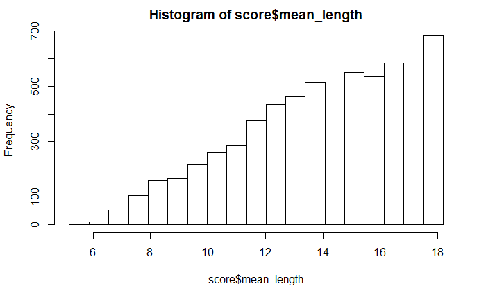

```r
score = h2o.predict(isofor_model, music_data[, 4:13])
result_pred = as.vector(score$predict)
mean_length = as.vector(score$mean_length)
h2o.hist(score$mean_length, breaks = 20)
```

The predictions from the isolation forest return the mean_length. This is the average number of splits it took to isolate the record across all the decision trees in the forest. Records with a smaller mean_length are more likely to be anomalous since it takes fewer partitions of the data to isolate them.

The histogram of the mean_length shows that most people have a mean_length greater than 10. This means that it takes more than 10 splits on average to partition them.

# Defining anomalies using mean length

We will define an anomaly as anyone who’s mean_length is less than 10 These were patients who were easier to isolate from the rest of the data.

```r
anomalies_ml = complete_data_selectedvars[as.vector(score$mean_length) < 10, ]
paste0("Number of Anomilies: ", nrow(anomalies_ml))
```

```
[1] "Number of Anomilies: 981"
```

# Defining anomalies using normalized anomaly score

- redo by labeling top 20% of outliers
- build new model to predict outliers using random forest -> generate a tree diagram
- predict_contributions.H20Model - diff from variable importance; gives contribitions of each column to the prediction
- present in 1-2 weeks; see if we can get a relevant cutoff/threshold (when it should not display a bar plot)
- consider outputting an anomaly score in the shiny app (isolation forest can predict a new anomaly score)
- determine why each patient is abnormal using the predict_contributions score

```r
# Score limit to filter data anomalies.
scorelimit = round(quantile(result_pred, probs = .90), 4)

anomaly = ifelse(result_pred > scorelimit, 1, 0)

# Add row score at the beginning of dataset
complete_data_selectedvars_sc = cbind(anom_score = round(result_pred, 4),
                                      mean_length,
                                      anomaly,
                                      complete_data_selectedvars)

# Get data anomalies by filtering all data.
anomalies_sc = complete_data_selectedvars_sc[complete_data_selectedvars_sc$rowscore > scorelimit,]

summary(anomalies_sc)
```

```
   anom_score   mean_length     anomaly        bxdate      practice
 Min.   : NA   Min.   : NA   Min.   : NA   Min.   :NA   Min.   : NA
 1st Qu.: NA   1st Qu.: NA   1st Qu.: NA   1st Qu.:NA   1st Qu.: NA
 Median : NA   Median : NA   Median : NA   Median :NA   Median : NA
 Mean   :NaN   Mean   :NaN   Mean   :NaN   Mean   :NA   Mean   :NaN
 3rd Qu.: NA   3rd Qu.: NA   3rd Qu.: NA   3rd Qu.:NA   3rd Qu.: NA
 Max.   : NA   Max.   : NA   Max.   : NA   Max.   :NA   Max.   : NA
                        primary_tx     age_rc         psa           bxgs         bxgs1
 Active_surveillance         :0    Min.   : NA   Min.   : NA   Min.   : NA   Min.   : NA
 Androgen_deprivation_therapy:0    1st Qu.: NA   1st Qu.: NA   1st Qu.: NA   1st Qu.: NA
 Radiation                   :0    Median : NA   Median : NA   Median : NA   Median : NA
 Radical_prostatectomy       :0    Mean   :NaN   Mean   :NaN   Mean   :NaN   Mean   :NaN
 Watchful_waiting            :0    3rd Qu.: NA   3rd Qu.: NA   3rd Qu.: NA   3rd Qu.: NA
                                   Max.   : NA   Max.   : NA   Max.   : NA   Max.   : NA
     bxgs2        totcores      poscores        wgt        mi     diab
 Min.   : NA   Min.   : NA   Min.   : NA   Min.   : NA   No :0   No :0
 1st Qu.: NA   1st Qu.: NA   1st Qu.: NA   1st Qu.: NA   Yes:0   Yes:0
 Median : NA   Median : NA   Median : NA   Median : NA
 Mean   :NaN   Mean   :NaN   Mean   :NaN   Mean   :NaN
 3rd Qu.: NA   3rd Qu.: NA   3rd Qu.: NA   3rd Qu.: NA
 Max.   : NA   Max.   : NA   Max.   : NA   Max.   : NA
```